# Lab 10

Gaines

11/15/2021

**1. Your task is to obtain the data from the following paper and conduct a reproducible analysis of their results. Rosenbaum, D., Mama, Y., & Algom, D. (2017). Stand by Your Stroop: Standing Up Enhances Selective Attention and Cognitive Control. Psychological science, 28(12), 1864-1867.Note, the paper, the data, and an existing reproducible analysis of this data is available at https://crumplab.github.io/statisticsLab/lab-10-factorial-anova.html#important-stuff-4**

#Aquiring data

```r
library(ggplot2)
library(dplyr)
library(papaja)
library(data.table)
incongruentdata <- fread("Downloads/stroop_stand.csv")
```

#manipulating data in to long format as walked through in class

```r
RTs <- c(as.numeric(unlist(incongruentdata[,1])),
         as.numeric(unlist(incongruentdata[,2])),
         as.numeric(unlist(incongruentdata[,3])),
         as.numeric(unlist(incongruentdata[,4]))
         )

Congruency <- rep(rep(c("Congruent","Incongruent"),each=50),2)
Posture <- rep(c("Stand","Sit"),each=100)
Subject <- rep(1:50,4)

stroop_df <- data.frame(Subject,Congruency,Posture,RTs)
```

**a. The re-analysis should focus only on Experiment 3. There are three main goals. Reproduce as much of the analysis as possible using only paired-sample t-tests. Note, the authors reported a 2x2 repeated measures ANOVA, but consider how the same questions could be answered by t-tests (2 points).**

#Reanalysis Test 1 experiment 3, sitting condition, congruent and incongruent stimuli

```r
(sit_stroop <- t.test(incongruentdata$congruent_sit,
      incongruentdata$incongruent_sit,
       paired = TRUE))
```

```
##
##  Paired t-test
##
## data:  incongruentdata$congruent_sit and incongruentdata$incongruent_sit
## t = -16.516, df = 49, p-value < 2.2e-16
## alternative hypothesis: true difference in means is not equal to 0
## 95 percent confidence interval:
##  -133.3250 -104.3997
## sample estimates:
## mean of the differences
##               -118.8623
```

About this analysis equivalent, the authors say: *“the sitting condition, M = 118.9 ms, t(49) = 16.52, p < .01, d = 2.376”* (Rosenbaum et al, 1866)

We found the same mean difference (M = 118.9 ms, incongruent stimuli has larger delay than congruent stimuli) and a p value <.01.

#Reanalysis Test 1 experiment 3, standing condition, congruent and incongruent stimuli

```r
(stand_stroop <- t.test(incongruentdata$congruent_stand,
      incongruentdata$incongruent_stand,
       paired = TRUE))
```

```
##
##  Paired t-test
##
## data:  incongruentdata$congruent_stand and incongruentdata$incongruent_stand
## t = -14.327, df = 49, p-value < 2.2e-16
## alternative hypothesis: true difference in means is not equal to 0
## 95 percent confidence interval:
##  -109.41185  -82.49462
## sample estimates:
## mean of the differences
##               -95.95323
```

About this analysis equivalent, the authors say: *“the standing condition, M = 95.9 ms, t(49) = 14.327, p < .01, d = 2.034”*(Rosenbaum et al, 1866)

We found the same mean difference (M = 95.9 ms, incongruent stimuli has larger delay than congruent stimuli) and a p value <.01.

#Reanalysis Test 1 experiment 3, comparing standing to sitting

```r
stand_stroop_scores <- incongruentdata$incongruent_stand-incongruentdata$congruent_stand
sit_stroop_scores <- incongruentdata$incongruent_sit-incongruentdata$congruent_sit
stroop_differences <- sit_stroop_scores - stand_stroop_scores
(paired_results <- t.test(stand_stroop_scores,
                         sit_stroop_scores,
                         paired=TRUE))
```

```
##
##  Paired t-test
##
## data:  stand_stroop_scores and sit_stroop_scores
## t = -2.9941, df = 49, p-value = 0.004306
## alternative hypothesis: true difference in means is not equal to 0
## 95 percent confidence interval:
##  -38.285366  -7.532845
## sample estimates:
## mean of the differences
##               -22.90911
```

```r
(interaction_results <- t.test(stroop_differences))
```

```
##
##  One Sample t-test
##
## data:  stroop_differences
## t = 2.9941, df = 49, p-value = 0.004306
## alternative hypothesis: true mean is not equal to 0
## 95 percent confidence interval:
##   7.532845 38.285366
## sample estimates:
## mean of x
##  22.90911
```

This difference in differences of reaction times (“shrinking” of the delay when particpants are standing) is the meat of what the authors are trying to claim.

*“the most significant finding again was the shrinkage of the effect when participants were standing, F(1, 49) = 8.964, p = .004, ηp2 = .155.”* (Rosenbaum et al, 1866)

We found the same p-value using a one-sample t-test, $M = 22.91$, 95% CI $[7.53$, $38.29]$, $t(49) = 2.99$, $p = .004$.

*Self Assesment: 70*

**b. Reproduce a graph of the means, like shown in the paper (2 points)**

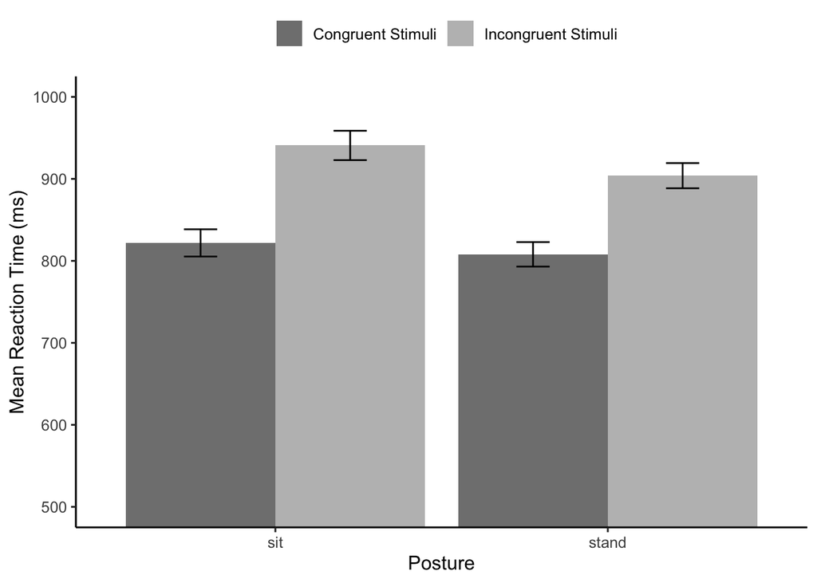

```r
library(tidyr)
# convert to long
stroop_df <- incongruentdata %>%
  pivot_longer(cols = 1:4,
               names_to = c("Congruency","Posture"),
               names_sep = "_",
               values_to = "RTs")
# get means
overall_means <- stroop_df %>%
                  group_by(Posture,Congruency) %>%
                  summarise(meanRT = mean(RTs),
                            SEMRT = (sd(RTs)/sqrt(length(RTs))))
# plot
ggplot(overall_means, aes(x=Posture,
                          y=meanRT,
                          fill=Congruency))+
  geom_bar(stat="identity",position="dodge")+
  theme_classic(base_size=12)+scale_fill_manual(values = c("#808080",
                               "#BEBEBE"), labels = c("Congruent Stimuli", "Incongruent Stimuli"))+
  ylab("Mean Reaction Time (ms)")+
  geom_errorbar(aes(ymin=meanRT-SEMRT,
                    ymax=meanRT+SEMRT),
                position=position_dodge(width=0.9),
                width=.2,
                color="black")+theme(legend.position="top")+ theme(legend.title = element_blank())+
  coord_cartesian(ylim=c(500,1000))
```

*Self-Assessment: 100*

**c. Present a power-curve analysis for the design. (2 points)**

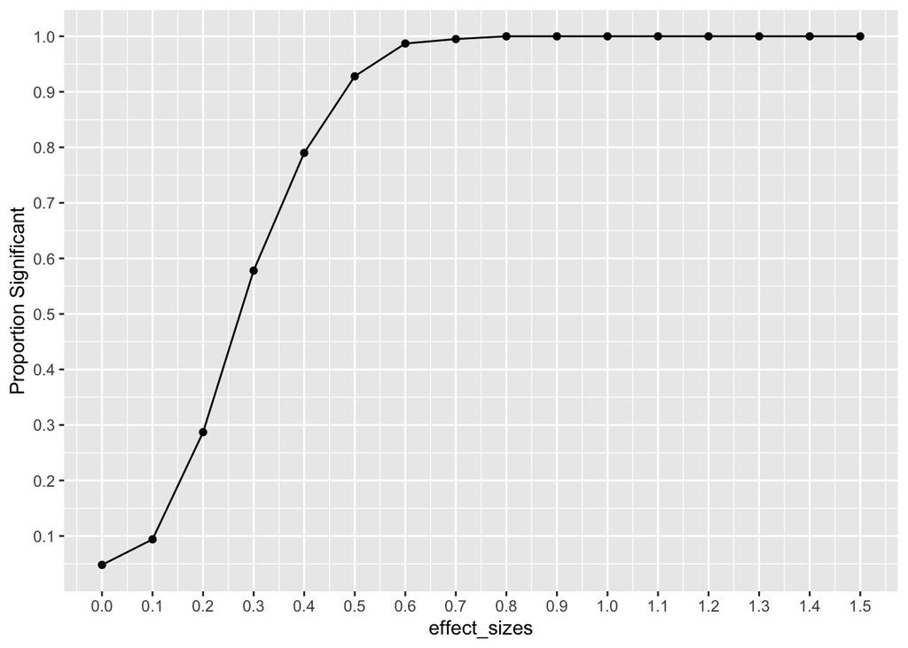

```r
effect_sizes <- seq(0,1.5,.1)
prop_significant <-c()
for(i in 1:length(effect_sizes)){
  sim_ps <- replicate(1000, t.test(replicate(50, rnorm(1, effect_sizes[i], 1)),
                                   mu = 0)$p.value)

  prop_significant[i] <- length(sim_ps[sim_ps < .05])/1000
}
plot_df <- data.frame(effect_sizes,
                      prop_significant)
ggplot(plot_df, aes(x=effect_sizes,y=prop_significant))+
  geom_line() +
  geom_point() +
  scale_x_continuous(breaks=seq(0,1.5,.1))+
  scale_y_continuous(breaks=seq(0,1,.1)) +
  ylab("Proportion Significant")
```

According to our power curve, with a sample size of 50 we are 80% powered around a .4 effect size. According to the authors, *“Increasing the number of participants to 50 provided a power of .92 to detect a medium-sized effect.”* (Rosenbaum et al, 1865). They must have considered .5 a medium-sized effect.

*Self-Assessment: 30*